# Analyzing Individual BGG Users

Phil Henrickson

2021-12-06

Load previously queried training and test data from the local layer.

Set function for displaying probabilities

Fit models and analyze collection for **rahdo**.

## Games in Collection

How many games has the user owned/played in the training set (games prior to 2020)?

```
## # A tibble: 1 × 3
##   username games_owned games_played
##   <chr>          <dbl>        <dbl>
## 1 rahdo            315          305
```

## Coefficients for rahdo

Examine coefficients from the trained model.

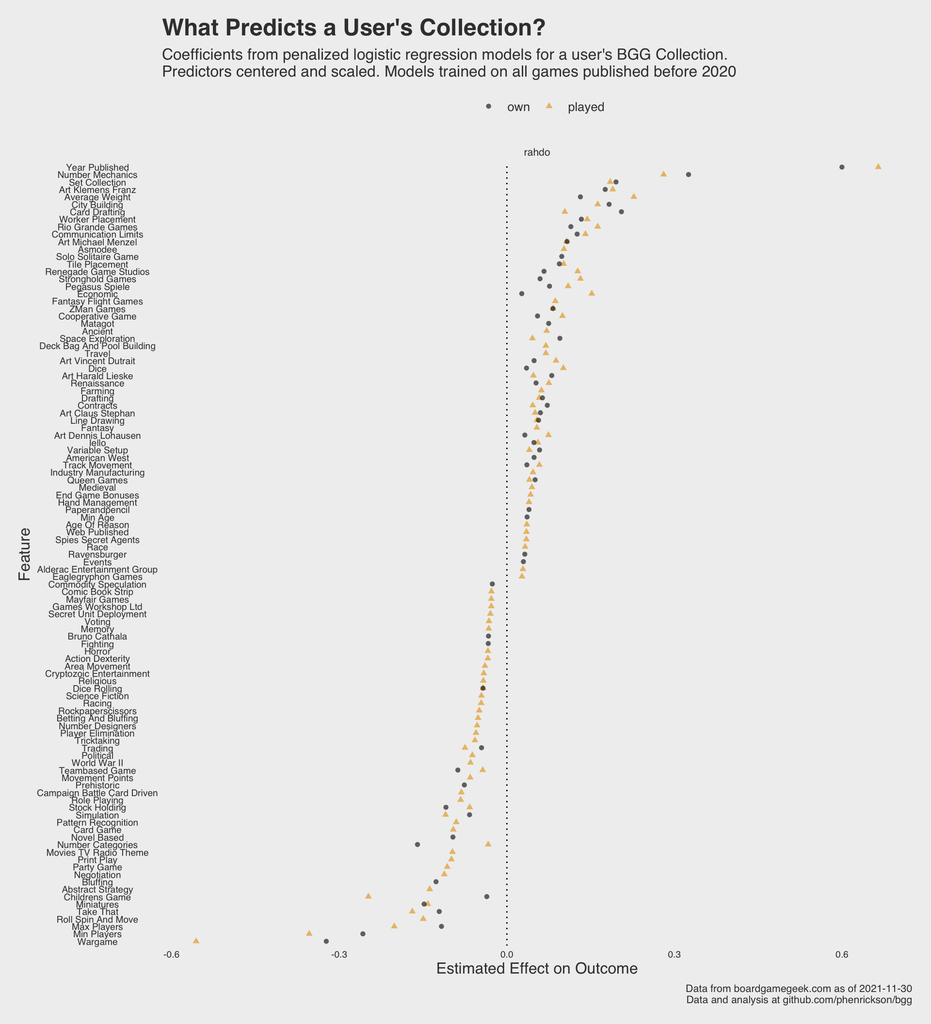

## Visualizing Predictors for rahdo’s Collection

Examine density of most important features for predicting whether user owns a game.

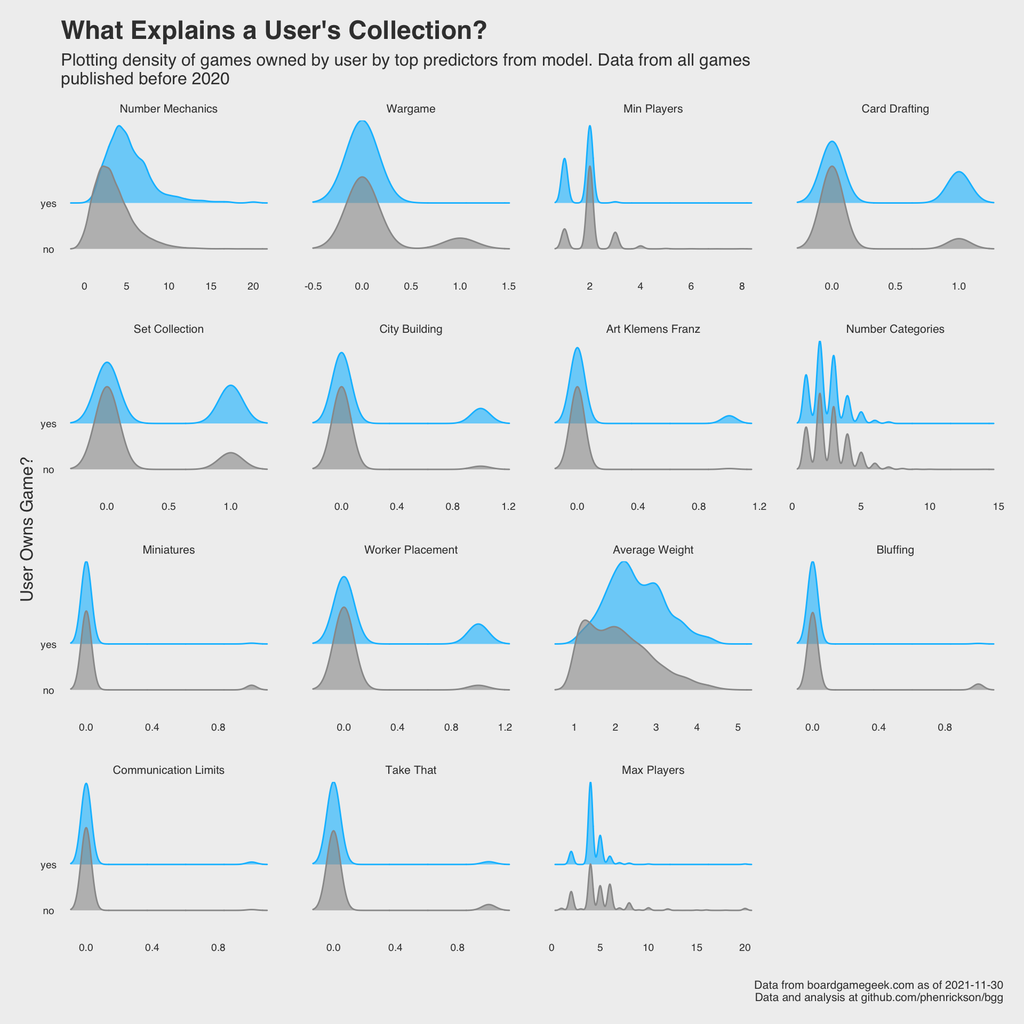

## Assessment

Examine separation plot for training set (cross validated predictions).

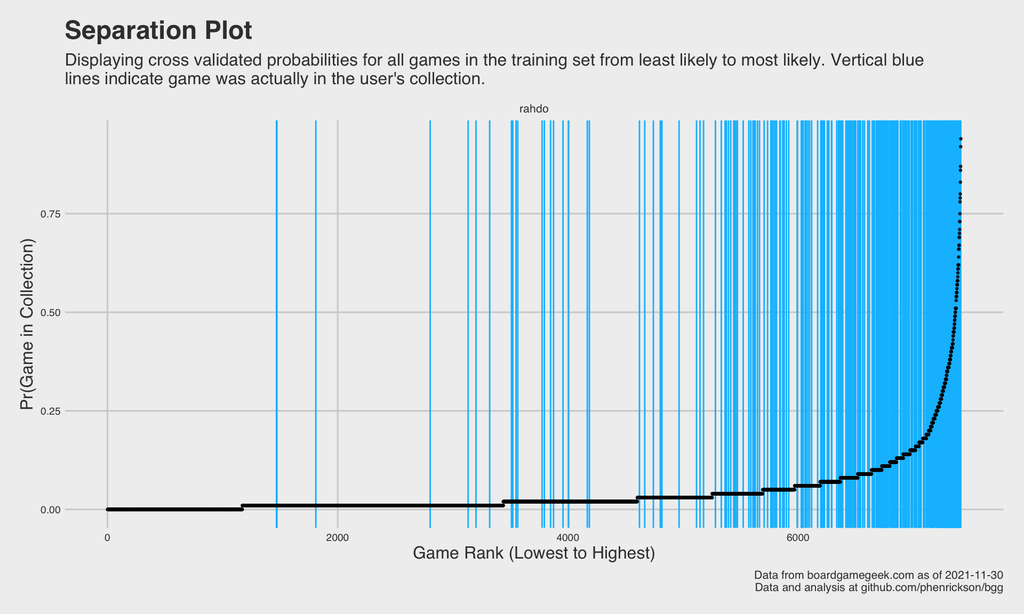

Formally assess how well the model did in resampling.

| outcome_type | .metric | .estimator | .estimate |
| --- | --- | --- | --- |
| own | roc_auc | binary | 0.895 |
| played | roc_auc | binary | 0.879 |

## Predicted Games in Collection from Training

Examine top games from resampling.

Top Overall Games for User from Resampling

| username | yearpublished | game_id | name | pred_played | pred_own | actual_played | actual_own |
| --- | --- | --- | --- | --- | --- | --- | --- |
| rahdo | 2018 | 244711 | Newton | 1.00 | 0.94 | 1 | 0 |
| rahdo | 2019 | 283863 | The Magnificent | 0.98 | 0.92 | 1 | 1 |
| rahdo | 2018 | 199792 | Everdell | 0.91 | 0.87 | 0 | 0 |
| rahdo | 2019 | 266524 | PARKS | 0.93 | 0.86 | 1 | 0 |
| rahdo | 2009 | 39683 | At the Gates of Loyang | 0.98 | 0.83 | 1 | 1 |
| rahdo | 2008 | 35677 | Le Havre | 0.96 | 0.80 | 1 | 0 |
| rahdo | 2007 | 31260 | Agricola | 0.97 | 0.79 | 1 | 1 |
| rahdo | 2012 | 123260 | Suburbia | 0.97 | 0.78 | 1 | 0 |
| rahdo | 2017 | 220308 | Gaia Project | 0.94 | 0.75 | 1 | 0 |
| rahdo | 2017 | 216132 | Clans of Caledonia | 0.93 | 0.73 | 1 | 0 |
| rahdo | 2012 | 122515 | Keyflower | 0.96 | 0.73 | 1 | 1 |
| rahdo | 2019 | 253635 | Ragusa | 0.94 | 0.71 | 1 | 0 |
| rahdo | 2016 | 200680 | Agricola (Revised Edition) | 0.97 | 0.70 | 0 | 0 |
| rahdo | 2015 | 182874 | Grand Austria Hotel | 0.93 | 0.69 | 1 | 1 |
| rahdo | 2018 | 246663 | NEOM | 0.87 | 0.69 | 1 | 1 |
| rahdo | 2019 | 257066 | Sierra West | 0.95 | 0.67 | 1 | 1 |
| rahdo | 2017 | 201825 | Ex Libris | 0.90 | 0.67 | 1 | 0 |
| rahdo | 2014 | 154203 | Imperial Settlers | 0.79 | 0.66 | 1 | 0 |
| rahdo | 2017 | 197376 | Charterstone | 0.83 | 0.66 | 1 | 1 |
| rahdo | 2019 | 264052 | Circadians: First Light | 0.92 | 0.64 | 1 | 1 |
| rahdo | 2016 | 192836 | The Colonists | 0.90 | 0.62 | 1 | 0 |
| rahdo | 2018 | 241831 | Reykholt | 0.93 | 0.62 | 1 | 0 |
| rahdo | 2018 | 245928 | Pax Emancipation | 0.96 | 0.62 | 0 | 0 |
| rahdo | 2014 | 156009 | Port Royal | 0.85 | 0.62 | 1 | 1 |
| rahdo | 2012 | 121921 | Robinson Crusoe: Adventures on the Cursed Island | 0.96 | 0.61 | 0 | 0 |
| rahdo | 2010 | 70512 | Luna | 0.92 | 0.61 | 1 | 1 |
| rahdo | 2019 | 217576 | Hellenica: Story of Greece | 0.84 | 0.60 | 0 | 0 |
| rahdo | 2018 | 214032 | Founders of Gloomhaven | 0.93 | 0.59 | 0 | 0 |
| rahdo | 2014 | 155173 | Subdivision | 0.84 | 0.58 | 1 | 1 |
| rahdo | 2019 | 260710 | Amul | 0.84 | 0.58 | 0 | 0 |

[output cut: 70 more lines]

### Most and Least Likely Games

What game does the model think rahdo is **most likely to own** that is **not** in their collection?

| username | yearpublished | game_id | name | pred_own |
| --- | --- | --- | --- | --- |
| rahdo | 2018 | 244711 | Newton | 0.94 |

What game does the model think rahdo is **least likely to own** that **is** in their collection?

| username | yearpublished | game_id | name | pred_own |
| --- | --- | --- | --- | --- |
| rahdo | 2013 | 143994 | Capo Dei Capi | 0.01 |

### Top Games by Year

Top 25 games most likely to be owned by the user in each year, highlighting in blue the games that the user has owned/played.

| rank | 2012 | 2013 | 2014 | 2015 | 2016 | 2017 | 2018 | 2019 |
| --- | --- | --- | --- | --- | --- | --- | --- | --- |
| 1 | Suburbia | Lewis & Clark: The Expedition | Imperial Settlers | Grand Austria Hotel | Agricola (Revised Edition) | Gaia Project | Newton | The Magnificent |
| 2 | Keyflower | Legacy: The Testament of Duke de Crecy | Port Royal | Between Two Cities | The Colonists | Clans of Caledonia | Everdell | PARKS |
| 3 | Robinson Crusoe: Adventures on the Cursed Island | Rococo | Subdivision | Porta Nigra | Terraforming Mars | Ex Libris | NEOM | Ragusa |
| 4 | Snowdonia | Glass Road | Fields of Arle | My Village | Inis | Charterstone | Reykholt | Sierra West |
| 5 | Il Vecchio | Caverna: The Cave Farmers | La Granja | Mombasa | Great Western Trail | Sagrada | Pax Emancipation | Circadians: First Light |
| 6 | Ginkgopolis | Bremerhaven | Castles of Mad King Ludwig | 504 | Yokohama | Noria | Founders of Gloomhaven | Hellenica: Story of Greece |
| 7 | Saint Malo | Concordia | Istanbul | Discoveries: The Journals of Lewis & Clark | Aeon's End | Gloomhaven | Architects of the West Kingdom | Amul |
| 8 | Targi | The Ravens of Thri Sahashri | Saint Petersburg (Second Edition) | FUSE | Lorenzo il Magnifico | Montana | CO₂: Second Chance | Tapestry |
| 9 | Among the Stars | Carcassonne: South Seas | Roll for the Galaxy | Viticulture Essential Edition | La Granja: No Siesta | Circle the Wagons | Teotihuacan: City of Gods | The Isle of Cats |
| 10 | Agricola: All Creatures Big and Small | Patchistory | Patchwork | Harbour | 51st State: Master Set | First Martians: Adventures on the Red Planet | Forum Trajanum | Masters of Renaissance: Lorenzo il Magnifico – The Card Game |
| 11 | Milestones | Händler der Karibik | Praetor | New York 1901 | Coal Baron: The Great Card Game | Lisboa | Sprawlopolis | Noctiluca |
| 12 | Kairo | Amerigo | Nations: The Dice Game | The Pursuit of Happiness | Port Royal: Unterwegs! | Riverboat | Rise to Nobility | Maracaibo |
| 13 | OddVille | Craftsmen | Onirim (Second Edition) | The Voyages of Marco Polo | The Castles of Burgundy: The Card Game | Gentes | Renegade | Barrage |
| 14 | Yedo | Bruges | Splendor | Parfum | A Feast for Odin | Tybor the Builder | Robin Hood and the Merry Men | Tiny Towns |
| 15 | CO₂ | Canalis | Pandemic: The Cure | Dilluvia Project | Martians: A Story of Civilization | Altiplano | Crown of Emara | Carnival of Monsters |
| 16 | Terra Mystica | Gravwell: Escape from the 9th Dimension | Murano | Coffee Roaster | Black Orchestra | Santa Maria | Patchwork Express | Florenza Dice Game |
| 17 | Tokaido | Palmyra | Roll Through the Ages: The Iron Age | Inhabit the Earth | Fields of Green | Paper Tales | Coimbra | Century: A New World |
| 18 | Card City | The Capitals | San Juan (Second Edition) | Isle of Skye: From Chieftain to King | Explorers of the North Sea | Caverna: Cave vs Cave | Underwater Cities | Paladins of the West Kingdom |
| 19 | Copycat | Firefly: The Game | Artifacts, Inc. | Trambahn | Covert | Magic Maze | The Grizzled: Armistice Edition | Clank!: Legacy – Acquisitions Incorporated |
| 20 | The Palaces of Carrara | Renaissance Man | The Staufer Dynasty | Trickerion: Legends of Illusion | First Class: All Aboard the Orient Express! | Alien Artifacts | Cosmic Run: Regeneration | Chai |
| 21 | Space Cadets | Thebes: The Tomb Raiders | Johari | Shakespeare | The Oregon Trail Card Game | Spirit Island | Gnomopolis | Aeon's End: Legacy |
| 22 | Lords of Waterdeep | Upon a Fable | Orléans | Raiders of the North Sea | Star Trek: The Dice Game | Too Many Bones | New Frontiers | Aerion |
| 23 | Sunrise City | Gear & Piston | Alchemists | The King Is Dead | Star Trek: Frontiers | Pocket Mars | Yellow & Yangtze | Queenz: To Bee or Not to Bee |
| 24 | Maharani | Packet Row | Limes | Tiny Epic Galaxies | Roll Player | Keyper | Realm of Sand | Coloma |
| 25 | Clash of Cultures | Bruxelles 1893 | VivaJava: The Coffee Game: The Dice Game | Steam Time | Agricola: Family Edition | This War of Mine: The Board Game | That's Pretty Clever! | Wingspan |

### Interactive Table

Interactive table for predictions from resampling.

|  | username | yearpublished | rank | game_id | name | pred_played | pred_own | actual_played | actual_own |
| --- | --- | --- | --- | --- | --- | --- | --- | --- | --- |
| 1 | rahdo | 1900 | 6248 | 5546 | Marbles | 0 | 0 | 0 | 0 |
| 2 | rahdo | 1900 | 6249 | 11901 | Tic-Tac-Toe | 0 | 0 | 0 | 0 |
| 3 | rahdo | 1900 | 6272 | 188 | Go | 0 | 0 | 0 | 0 |
| 4 | rahdo | 1900 | 6317 | 171 | Chess | 0 | 0 | 0 | 0 |
| 5 | rahdo | 1900 | 6321 | 2065 | Shogi | 0 | 0 | 0 | 0 |
| 6 | rahdo | 1900 | 6322 | 2393 | Xiangqi | 0 | 0 | 0 | 0 |
| 7 | rahdo | 1900 | 6371 | 26952 | International Checkers | 0 | 0 | 0 | 0 |
| 8 | rahdo | 1900 | 6377 | 1602 | The Royal Game of Ur | 0 | 0 | 0 | 0 |
| 9 | rahdo | 1900 | 6378 | 2083 | Checkers | 0 | 0 | 0 | 0 |
| 10 | rahdo | 1900 | 6382 | 2389 | Othello | 0 | 0 | 0 | 0 |

[output cut: 7403 more lines]

## Predicted Games in Collection 2020 and On

Examine the top games for the test set.

Top Predicted Games for User, 2020 and On

| username | yearpublished | game_id | name | rank | own | played |
| --- | --- | --- | --- | --- | --- | --- |
| rahdo | 2020 | 184267 | On Mars | 1 | 0.97 | 0.99 |
| rahdo | 2020 | 300322 | Hallertau | 2 | 0.75 | 0.99 |
| rahdo | 2020 | 306040 | Merv: The Heart of the Silk Road | 3 | 0.73 | 0.96 |
| rahdo | 2020 | 284742 | Honey Buzz | 4 | 0.65 | 0.89 |
| rahdo | 2020 | 308765 | Praga Caput Regni | 5 | 0.61 | 0.96 |
| rahdo | 2020 | 306481 | Tawantinsuyu: The Inca Empire | 6 | 0.60 | 0.76 |
| rahdo | 2020 | 292333 | Cowboys II: Cowboys & Indians Edition | 7 | 0.56 | 0.26 |
| rahdo | 2020 | 313349 | Indus 2500 BCE | 8 | 0.48 | 0.66 |
| rahdo | 2020 | 301716 | Glasgow | 9 | 0.47 | 0.88 |
| rahdo | 2020 | 318983 | Faiyum | 10 | 0.46 | 0.95 |
| rahdo | 2020 | 313698 | Monster Expedition | 11 | 0.46 | 0.88 |
| rahdo | 2020 | 301880 | Raiders of Scythia | 12 | 0.46 | 0.88 |
| rahdo | 2020 | 304420 | Bonfire | 13 | 0.46 | 0.84 |
| rahdo | 2020 | 306735 | Under Falling Skies | 14 | 0.45 | 0.80 |
| rahdo | 2020 | 291457 | Gloomhaven: Jaws of the Lion | 15 | 0.44 | 0.88 |
| rahdo | 2020 | 291511 | Medici: The Dice Game | 16 | 0.42 | 0.78 |
| rahdo | 2020 | 317985 | Beyond the Sun | 17 | 0.42 | 0.60 |
| rahdo | 2020 | 296151 | Viscounts of the West Kingdom | 18 | 0.41 | 0.92 |
| rahdo | 2020 | 233262 | Tidal Blades: Heroes of the Reef | 19 | 0.41 | 0.69 |
| rahdo | 2020 | 267009 | Rome & Roll | 20 | 0.41 | 0.85 |
| rahdo | 2020 | 295486 | My City | 21 | 0.38 | 0.74 |
| rahdo | 2020 | 307844 | Atheneum: Mystic Library | 22 | 0.37 | 0.82 |
| rahdo | 2020 | 298017 | Treelings | 23 | 0.35 | 0.70 |
| rahdo | 2020 | 312804 | Pendulum | 24 | 0.34 | 0.59 |
| rahdo | 2020 | 302310 | Nanaki | 25 | 0.34 | 0.78 |
| rahdo | 2021 | 298102 | Roll Camera!: The Filmmaking Board Game | 1 | 0.85 | 0.94 |
| rahdo | 2021 | 343905 | Boonlake | 2 | 0.85 | 1.00 |
| rahdo | 2021 | 249277 | Brazil: Imperial | 3 | 0.73 | 0.96 |
| rahdo | 2021 | 342942 | Ark Nova | 4 | 0.68 | 0.96 |
| rahdo | 2021 | 282776 | Tumble Town | 5 | 0.57 | 0.82 |
| rahdo | 2021 | 252752 | Genotype: A Mendelian Genetics Game | 6 | 0.56 | 0.79 |
| rahdo | 2021 | 260524 | Beyond Humanity: Colonies | 7 | 0.55 | 0.83 |
| rahdo | 2021 | 341169 | Great Western Trail (Second Edition) | 8 | 0.52 | 0.92 |
| rahdo | 2021 | 340677 | Bad Company | 9 | 0.50 | 0.70 |
| rahdo | 2021 | 328286 | Mission ISS | 10 | 0.49 | 0.77 |
| rahdo | 2021 | 344277 | Corrosion | 11 | 0.48 | 0.85 |
| rahdo | 2021 | 314088 | Agropolis | 12 | 0.47 | 0.67 |
| rahdo | 2021 | 292126 | Excavation Earth | 13 | 0.45 | 0.66 |
| rahdo | 2021 | 310873 | Carnegie | 14 | 0.44 | 0.88 |
| rahdo | 2021 | 257706 | Zoo-ography | 15 | 0.43 | 0.55 |
| rahdo | 2021 | 316786 | Tabannusi: Builders of Ur | 16 | 0.43 | 0.89 |
| rahdo | 2021 | 298378 | Maharaja | 17 | 0.42 | 0.78 |
| rahdo | 2021 | 341048 | Free Ride | 18 | 0.42 | 0.69 |
| rahdo | 2021 | 309319 | Apogee | 19 | 0.41 | 0.81 |
| rahdo | 2021 | 292899 | Tribune | 20 | 0.39 | 0.82 |
| rahdo | 2021 | 238799 | Messina 1347 | 21 | 0.39 | 0.93 |
| rahdo | 2021 | 302461 | Intrepid | 22 | 0.38 | 0.68 |
| rahdo | 2021 | 320992 | The Specialists | 23 | 0.38 | 0.62 |
| rahdo | 2021 | 315234 | Embarcadero | 24 | 0.37 | 0.83 |
| rahdo | 2021 | 329593 | Settlement | 25 | 0.37 | 0.87 |
| rahdo | 2021 | 281248 | Cape May | 26 | 0.37 | 0.84 |
| rahdo | 2022 | 304051 | Creature Comforts | 1 | 0.71 | 0.94 |
| rahdo | 2022 | 317511 | Tindaya | 2 | 0.57 | 0.83 |
| rahdo | 2022 | 334065 | Verdant | 3 | 0.54 | 0.67 |
| rahdo | 2022 | 295770 | Frosthaven | 4 | 0.42 | 0.86 |
| rahdo | 2022 | 266018 | Trinidad | 5 | 0.39 | 0.89 |
| rahdo | 2022 | 305462 | The Age of Atlantis | 6 | 0.38 | 0.82 |
| rahdo | 2022 | 311988 | Frostpunk: The Board Game | 7 | 0.37 | 0.86 |
| rahdo | 2022 | 319807 | Shogun no Katana | 8 | 0.36 | 0.83 |
| rahdo | 2022 | 322289 | Darwin's Journey | 9 | 0.35 | 0.83 |
| rahdo | 2022 | 258779 | Planet Unknown | 10 | 0.35 | 0.71 |
| rahdo | 2022 | 330950 | Age of Galaxy | 11 | 0.34 | 0.63 |
| rahdo | 2022 | 323156 | Stroganov | 12 | 0.33 | 0.64 |
| rahdo | 2022 | 294880 | Chai: Tea for 2 | 13 | 0.33 | 0.51 |
| rahdo | 2022 | 335427 | Wild: Serengeti | 14 | 0.33 | 0.64 |
| rahdo | 2022 | 256997 | Perseverance: Castaway Chronicles – Episodes 1 & 2 | 15 | 0.31 | 0.75 |
| rahdo | 2022 | 305096 | Endless Winter: Paleoamericans | 16 | 0.29 | 0.81 |
| rahdo | 2022 | 326945 | Castles of Mad King Ludwig: Collector's Edition | 17 | 0.29 | 0.71 |
| rahdo | 2022 | 237179 | Weather Machine | 18 | 0.26 | 0.75 |
| rahdo | 2022 | 331106 | The Witcher: Old World | 19 | 0.24 | 0.81 |
| rahdo | 2022 | 273814 | Deliverance | 20 | 0.21 | 0.38 |
| rahdo | 2022 | 336986 | Flamecraft | 21 | 0.19 | 0.65 |
| rahdo | 2022 | 295895 | Distilled | 22 | 0.18 | 0.59 |
| rahdo | 2022 | 313065 | Transmissions | 23 | 0.17 | 0.54 |
| rahdo | 2022 | 322589 | Zapotec | 24 | 0.17 | 0.52 |
| rahdo | 2022 | 322524 | Bardsung | 25 | 0.15 | 0.23 |

Interactive table for 2020 and On

|  | username | yearpublished | game_id | name | rank | own | played |
| --- | --- | --- | --- | --- | --- | --- | --- |
| 1 | rahdo | 2020 | 184267 | On Mars | 1 | 0.97 | 0.99 |
| 2 | rahdo | 2021 | 298102 | Roll Camera!: The Filmmaking Board Game | 2 | 0.85 | 0.94 |
| 3 | rahdo | 2021 | 343905 | Boonlake | 3 | 0.85 | 1 |
| 4 | rahdo | 2020 | 300322 | Hallertau | 4 | 0.75 | 0.99 |
| 5 | rahdo | 2020 | 306040 | Merv: The Heart of the Silk Road | 5 | 0.73 | 0.96 |
| 6 | rahdo | 2021 | 249277 | Brazil: Imperial | 6 | 0.73 | 0.96 |
| 7 | rahdo | 2022 | 304051 | Creature Comforts | 7 | 0.71 | 0.94 |
| 8 | rahdo | 2021 | 342942 | Ark Nova | 8 | 0.68 | 0.96 |
| 9 | rahdo | 2020 | 284742 | Honey Buzz | 9 | 0.65 | 0.89 |
| 10 | rahdo | 2020 | 308765 | Praga Caput Regni | 10 | 0.61 | 0.96 |

[output cut: 1566 more lines]